# Análisis de Volúmenes de Venta y Rendimiento por Preventista

- Reporte Comparativo de Períodos - Septiembre/Agosto 2024
- Seguimiento de KPIs Comerciales por Vendedor
1. Nombre del preventista
2. Volumen Actual
3. Promedio Actual
4. Porcentaje de Bonificación
5. Porcentaje de Devolución
6. Volumen del Mes de Septiembre
7. Promedio de Septiembre
8. Variación respecto al Mes de Septiembre
9. Volumen de Cierre del Mes
10. Volumen de Cierre del Mes Anterior

Puedes usar este DataFrame para realizar diversos análisis, como:

- Calcular promedios
- Encontrar valores máximos y mínimos
- Hacer comparaciones entre períodos
- Crear visualizaciones

```python
import pandas as pd
import numpy as np
import matplotlib.pyplot as plt
import seaborn as sns
```

```python
# Crear diccionario con los datos
data = {
    'Nombre': [
        'CASAGRANDE DANIEL',
        'DE PAULA GUSTAVO',
        'TOLABA MARIANO',
        'WANVESTRANT JUAN',
        'CABRERA RODOLFO'
    ],
    'Volumen_Act': [37035, 48152, 74860, 33068, 45256],
    'Prom_Act': [1683, 2189, 3403, 1503, 2057],
    '%_Bonif': [10.9, 10.0, 16.8, 9.6, 10.4],
    '%_Dev': [1.7, 1.0, 0.5, 1.0, 0.7],
    'Volumen_Mes_Sep': [32919, 47806, 72528, 27648, 45716],
    'Prom_Sep': [1496, 2173, 3297, 1257, 2078],
    'Var_Mes_Sep': [12.5, 0.7, 3.2, 19.6, -1.0],
    'Volumen_Cierre_Mes_Septiembre': [45822, 73464, 110049, 59313, 66640],
    'Volumen_Cierre_Mes_Agosto': [51238, 66997, 118045, 40854, 63033]
}

data = pd.DataFrame(data)
data
```

|  | Nombre | Volumen_Act | Prom_Act | %_Bonif | %_Dev | Volumen_Mes_Sep | Prom_Sep | Var_Mes_Sep | Volumen_Cierre_Mes_Septiembre | Volumen_Cierre_Mes_Agosto |
| --- | --- | --- | --- | --- | --- | --- | --- | --- | --- | --- |
| 0 | CASAGRANDE DANIEL | 37035 | 1683 | 10.9 | 1.7 | 32919 | 1496 | 12.5 | 45822 | 51238 |
| 1 | DE PAULA GUSTAVO | 48152 | 2189 | 10.0 | 1.0 | 47806 | 2173 | 0.7 | 73464 | 66997 |
| 2 | TOLABA MARIANO | 74860 | 3403 | 16.8 | 0.5 | 72528 | 3297 | 3.2 | 110049 | 118045 |
| 3 | WANVESTRANT JUAN | 33068 | 1503 | 9.6 | 1.0 | 27648 | 1257 | 19.6 | 59313 | 40854 |
| 4 | CABRERA RODOLFO | 45256 | 2057 | 10.4 | 0.7 | 45716 | 2078 | -1.0 | 66640 | 63033 |

```python
data2 = data.copy()
data2
```

|  | Nombre | Volumen_Act | Prom_Act | %_Bonif | %_Dev | Volumen_Mes_Sep | Prom_Sep | Var_Mes_Sep | Volumen_Cierre_Mes_Septiembre | Volumen_Cierre_Mes_Agosto |
| --- | --- | --- | --- | --- | --- | --- | --- | --- | --- | --- |
| 0 | CASAGRANDE DANIEL | 37035 | 1683 | 10.9 | 1.7 | 32919 | 1496 | 12.5 | 45822 | 51238 |
| 1 | DE PAULA GUSTAVO | 48152 | 2189 | 10.0 | 1.0 | 47806 | 2173 | 0.7 | 73464 | 66997 |
| 2 | TOLABA MARIANO | 74860 | 3403 | 16.8 | 0.5 | 72528 | 3297 | 3.2 | 110049 | 118045 |
| 3 | WANVESTRANT JUAN | 33068 | 1503 | 9.6 | 1.0 | 27648 | 1257 | 19.6 | 59313 | 40854 |
| 4 | CABRERA RODOLFO | 45256 | 2057 | 10.4 | 0.7 | 45716 | 2078 | -1.0 | 66640 | 63033 |

```python
data2.info()
```

```
<class 'pandas.core.frame.DataFrame'>
RangeIndex: 5 entries, 0 to 4
Data columns (total 10 columns):
 #   Column                         Non-Null Count  Dtype
---  ------                         --------------  -----
 0   Nombre                         5 non-null      object
 1   Volumen_Act                    5 non-null      int64
 2   Prom_Act                       5 non-null      int64
 3   %_Bonif                        5 non-null      float64
 4   %_Dev                          5 non-null      float64
 5   Volumen_Mes_Sep                5 non-null      int64
 6   Prom_Sep                       5 non-null      int64
 7   Var_Mes_Sep                    5 non-null      float64
 8   Volumen_Cierre_Mes_Septiembre  5 non-null      int64
 9   Volumen_Cierre_Mes_Agosto      5 non-null      int64
dtypes: float64(3), int64(6), object(1)
memory usage: 528.0+ bytes
```

```python
data2_descriptiva = data2.describe().round(2)
data2_descriptiva
```

|  | Volumen_Act | Prom_Act | %_Bonif | %_Dev | Volumen_Mes_Sep | Prom_Sep | Var_Mes_Sep | Volumen_Cierre_Mes_Septiembre | Volumen_Cierre_Mes_Agosto |
| --- | --- | --- | --- | --- | --- | --- | --- | --- | --- |
| count | 5.00 | 5.00 | 5.00 | 5.00 | 5.0 | 5.00 | 5.00 | 5.0 | 5.00 |
| mean | 47674.20 | 2167.00 | 11.54 | 0.98 | 45323.4 | 2060.20 | 7.00 | 71057.6 | 68033.40 |
| std | 16368.24 | 744.22 | 2.98 | 0.45 | 17411.9 | 791.54 | 8.76 | 24085.3 | 29782.73 |
| min | 33068.00 | 1503.00 | 9.60 | 0.50 | 27648.0 | 1257.00 | -1.00 | 45822.0 | 40854.00 |
| 25% | 37035.00 | 1683.00 | 10.00 | 0.70 | 32919.0 | 1496.00 | 0.70 | 59313.0 | 51238.00 |
| 50% | 45256.00 | 2057.00 | 10.40 | 1.00 | 45716.0 | 2078.00 | 3.20 | 66640.0 | 63033.00 |
| 75% | 48152.00 | 2189.00 | 10.90 | 1.00 | 47806.0 | 2173.00 | 12.50 | 73464.0 | 66997.00 |
| max | 74860.00 | 3403.00 | 16.80 | 1.70 | 72528.0 | 3297.00 | 19.60 | 110049.0 | 118045.00 |

```python
data2.isnull().sum()
```

|  | 0 |
| --- | --- |
| Nombre | 0 |
| Volumen_Act | 0 |
| Prom_Act | 0 |
| %_Bonif | 0 |
| %_Dev | 0 |
| Volumen_Mes_Sep | 0 |
| Prom_Sep | 0 |
| Var_Mes_Sep | 0 |
| Volumen_Cierre_Mes_Septiembre | 0 |
| Volumen_Cierre_Mes_Agosto | 0 |

**dtype:** int64

```python
data2_transpuesta = data2.set_index('Nombre').T
data2_transpuesta
```

| Nombre | CASAGRANDE DANIEL | DE PAULA GUSTAVO | TOLABA MARIANO | WANVESTRANT JUAN | CABRERA RODOLFO |
| --- | --- | --- | --- | --- | --- |
| Volumen_Act | 37035.0 | 48152.0 | 74860.0 | 33068.0 | 45256.0 |
| Prom_Act | 1683.0 | 2189.0 | 3403.0 | 1503.0 | 2057.0 |
| %_Bonif | 10.9 | 10.0 | 16.8 | 9.6 | 10.4 |
| %_Dev | 1.7 | 1.0 | 0.5 | 1.0 | 0.7 |
| Volumen_Mes_Sep | 32919.0 | 47806.0 | 72528.0 | 27648.0 | 45716.0 |
| Prom_Sep | 1496.0 | 2173.0 | 3297.0 | 1257.0 | 2078.0 |
| Var_Mes_Sep | 12.5 | 0.7 | 3.2 | 19.6 | -1.0 |
| Volumen_Cierre_Mes_Septiembre | 45822.0 | 73464.0 | 110049.0 | 59313.0 | 66640.0 |
| Volumen_Cierre_Mes_Agosto | 51238.0 | 66997.0 | 118045.0 | 40854.0 | 63033.0 |

## Volumen actual por preventista

```python
data2_volumen_actual = data2[['Nombre','Volumen_Act']]
data2_volumen_actual
```

|  | Nombre | Volumen_Act |
| --- | --- | --- |
| 0 | CASAGRANDE DANIEL | 37035 |
| 1 | DE PAULA GUSTAVO | 48152 |
| 2 | TOLABA MARIANO | 74860 |
| 3 | WANVESTRANT JUAN | 33068 |
| 4 | CABRERA RODOLFO | 45256 |

```python
promedio_actual = data2[['Nombre', 'Prom_Act']]
promedio_actual
```

|  | Nombre | Prom_Act |
| --- | --- | --- |
| 0 | CASAGRANDE DANIEL | 1683 |
| 1 | DE PAULA GUSTAVO | 2189 |
| 2 | TOLABA MARIANO | 3403 |
| 3 | WANVESTRANT JUAN | 1503 |
| 4 | CABRERA RODOLFO | 2057 |

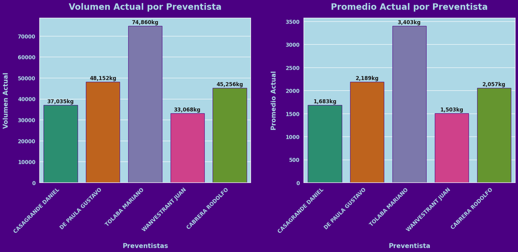

```python
sns.set_style('darkgrid')
sns.set_theme(rc={'axes.facecolor':'lightblue', 'figure.facecolor':'indigo'})
plt.figure(figsize=(20,7))
plt.subplot(1, 2, 1)
ax = sns.barplot(x=data2_volumen_actual['Nombre'], y=data2_volumen_actual['Volumen_Act'], edgecolor='indigo', hue=data2_volumen_actual['Nombre'], palette='Dark2')
plt.title('Volumen Actual por Preventista', color='lightblue', size=20, weight='bold',pad=20)
plt.xlabel('Preventistas', color='lightblue', size=15, weight='bold',labelpad=20)
plt.ylabel('Volumen Actual', color='lightblue', size=15, weight='bold',labelpad=20)
plt.xticks(ha='right', color='lightblue', size=12, weight='bold', rotation=45)
plt.yticks(color='lightblue', size=12, weight='bold')
for container in ax.containers:
    ax.bar_label(container,
                label_type='edge',
                padding=2,
                color='k',
                fontsize=12,
                fontweight='bold',
                fmt='{:,.0f}kg')
plt.subplot(1, 2, 2)
ax = sns.barplot(x=data2['Nombre'], y=promedio_actual['Prom_Act'], edgecolor='indigo', hue=data2['Nombre'], palette='Dark2')
plt.title('Promedio Actual por Preventista', color='lightblue', size=20, weight='bold',pad=20)
plt.ylabel('Promedio Actual', color='lightblue', size=15, weight='bold',labelpad=20)
plt.xlabel('Preventista', color='lightblue', size=15, weight='bold',labelpad=20)
plt.xticks(ha='right', color='lightblue', size=12, weight='bold', rotation=45)
plt.yticks(color='lightblue', size=12, weight='bold')
for container in ax.containers:
    ax.bar_label(container,
                label_type='edge',
                padding=2,
                color='k',
                fontsize=12,
                fontweight='bold',
                fmt='{:,.0f}kg')
plt.subplots_adjust(wspace=0.25)
plt.show()
```

```python
porcentaje_bonificacion = data2[['Nombre', '%_Bonif']]
porcentaje_bonificacion
```

|  | Nombre | %_Bonif |
| --- | --- | --- |
| 0 | CASAGRANDE DANIEL | 10.9 |
| 1 | DE PAULA GUSTAVO | 10.0 |
| 2 | TOLABA MARIANO | 16.8 |
| 3 | WANVESTRANT JUAN | 9.6 |
| 4 | CABRERA RODOLFO | 10.4 |

```python
porcentaje_devolucion = data2[['Nombre', '%_Dev']]
porcentaje_devolucion
```

|  | Nombre | %_Dev |
| --- | --- | --- |
| 0 | CASAGRANDE DANIEL | 1.7 |
| 1 | DE PAULA GUSTAVO | 1.0 |
| 2 | TOLABA MARIANO | 0.5 |
| 3 | WANVESTRANT JUAN | 1.0 |
| 4 | CABRERA RODOLFO | 0.7 |

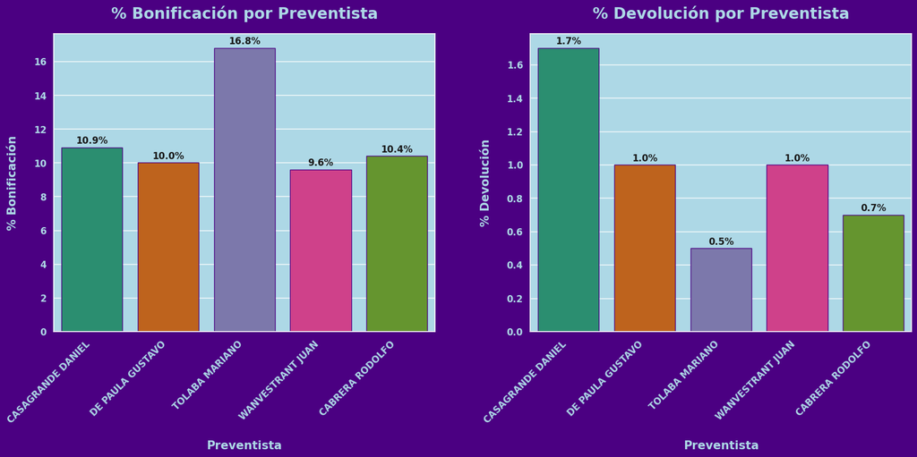

```python
sns.set_style('darkgrid')
sns.set_theme(rc={'axes.facecolor':'lightblue', 'figure.facecolor':'indigo'})
plt.figure(figsize=(20,7))
plt.subplot(1, 2, 1)
ax = sns.barplot(x=data2['Nombre'], y=porcentaje_bonificacion['%_Bonif'], edgecolor='indigo', hue=data2['Nombre'], palette='Dark2')
plt.title('% Bonificación por Preventista', color='lightblue', size=20, weight='bold',pad=20)
plt.ylabel('% Bonificación', color='lightblue', size=15, weight='bold',labelpad=20)
plt.xlabel('Preventista', color='lightblue', size=15, weight='bold',labelpad=20)
plt.xticks( ha='right', color='lightblue', size=12, weight='bold', rotation=45)
plt.yticks(color='lightblue', size=12, weight='bold')
for container in ax.containers:
    ax.bar_label(container,
                label_type='edge',
                padding=2,
                color='k',
                fontsize=12,
                fontweight='bold',
                fmt='{:,.1f}%')
plt.subplots_adjust(wspace=0.3)
plt.subplot(1, 2, 2)
ax = sns.barplot(x=data2['Nombre'], y=porcentaje_devolucion['%_Dev'], edgecolor='indigo', hue=data['Nombre'], palette='Dark2')
plt.title('% Devolución por Preventista', color='lightblue', size=20, weight='bold',pad=20)
plt.ylabel('% Devolución', color='lightblue', size=15, weight='bold',labelpad=20)
plt.xlabel('Preventista', color='lightblue', size=15, weight='bold',labelpad=20)
plt.xticks( ha='right', color='lightblue', size=12, weight='bold', rotation=45)
plt.yticks(color='lightblue', size=12, weight='bold')
for container in ax.containers:
    ax.bar_label(container,
                label_type='edge',
                padding=2,
                color='k',
                fontsize=12,
                fontweight='bold',
                fmt='{:,.1f}%')
plt.subplots_adjust(wspace=0.25)
plt.show()
```

```python
Volumen_Mes_Septiembre = data2[['Nombre', 'Volumen_Mes_Sep']]
Volumen_Mes_Septiembre
```

|  | Nombre | Volumen_Mes_Sep |
| --- | --- | --- |
| 0 | CASAGRANDE DANIEL | 32919 |
| 1 | DE PAULA GUSTAVO | 47806 |
| 2 | TOLABA MARIANO | 72528 |
| 3 | WANVESTRANT JUAN | 27648 |
| 4 | CABRERA RODOLFO | 45716 |

```python
variacion_septiembre = data2[['Nombre', 'Var_Mes_Sep']]
variacion_septiembre
```

|  | Nombre | Var_Mes_Sep |
| --- | --- | --- |
| 0 | CASAGRANDE DANIEL | 12.5 |
| 1 | DE PAULA GUSTAVO | 0.7 |
| 2 | TOLABA MARIANO | 3.2 |
| 3 | WANVESTRANT JUAN | 19.6 |
| 4 | CABRERA RODOLFO | -1.0 |

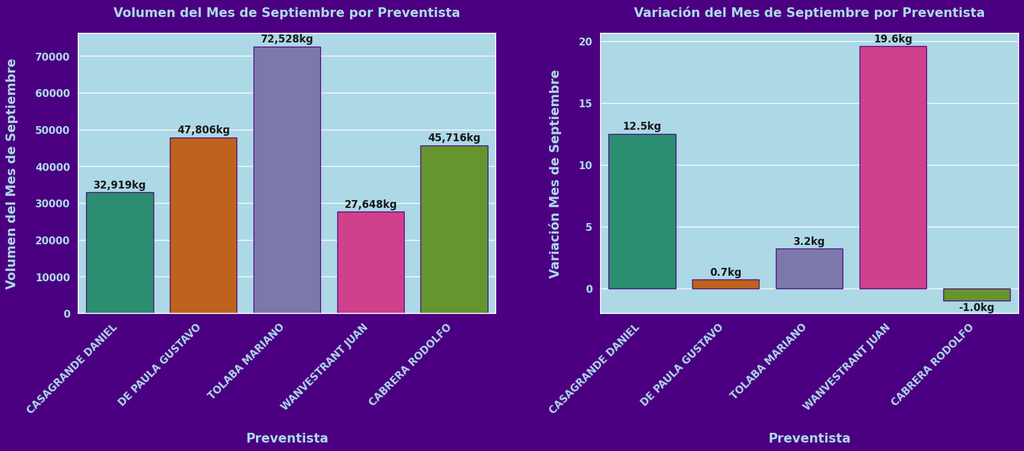

```python
sns.set_style('darkgrid')
sns.set_theme(rc={'axes.facecolor':'lightblue', 'figure.facecolor':'indigo'})
plt.figure(figsize=(20,6))
plt.subplot(1, 2, 1)
ax = sns.barplot(x=data2['Nombre'], y=Volumen_Mes_Septiembre['Volumen_Mes_Sep'], edgecolor='indigo', hue=data2['Nombre'], palette='Dark2')
plt.title('Volumen del Mes de Septiembre por Preventista', color='lightblue', size=15, weight='bold',pad=20)
plt.ylabel('Volumen del Mes de Septiembre', color='lightblue', size=15, weight='bold',labelpad=20)
plt.xlabel('Preventista', color='lightblue', size=15, weight='bold',labelpad=20)
plt.xticks(ha='right', color='lightblue', size=12, weight='bold', rotation=45)
plt.yticks(color='lightblue', size=12, weight='bold')
for container in ax.containers:
    ax.bar_label(container,
                label_type='edge',
                padding=2,
                color='k',
                fontsize=12,
                fontweight='bold',
                fmt='{:,.0f}kg')
plt.subplot(1,2,2)
ax = sns.barplot(x=data2['Nombre'], y=variacion_septiembre['Var_Mes_Sep'], edgecolor='indigo', hue=data['Nombre'], palette='Dark2')
plt.title('Variación del Mes de Septiembre por Preventista', color='lightblue', size=15, weight='bold',pad=20)
plt.ylabel('Variación Mes de Septiembre', color='lightblue', size=15, weight='bold',labelpad=20)
plt.xlabel('Preventista', color='lightblue', size=15, weight='bold',labelpad=20)
plt.xticks(rotation=45, ha='right', color='lightblue', size=12, weight='bold')
plt.yticks(color='lightblue', size=12, weight='bold')
for container in ax.containers:
    ax.bar_label(container,
                label_type='edge',
                padding=2,
                color='k',
                fontsize=12,
                fontweight='bold',
                fmt='{:,.1f}kg')
plt.subplots_adjust(wspace=0.25)
plt.show()
```

```python
Volumen_Cierre_Mes_Septiembre = data2[['Nombre', 'Volumen_Cierre_Mes_Septiembre']]
Volumen_Cierre_Mes_Septiembre
```

|  | Nombre | Volumen_Cierre_Mes_Septiembre |
| --- | --- | --- |
| 0 | CASAGRANDE DANIEL | 45822 |
| 1 | DE PAULA GUSTAVO | 73464 |
| 2 | TOLABA MARIANO | 110049 |
| 3 | WANVESTRANT JUAN | 59313 |
| 4 | CABRERA RODOLFO | 66640 |

```python
volumen_cierre_mes_de_agosto = data2[['Nombre', 'Volumen_Cierre_Mes_Agosto']]
volumen_cierre_mes_de_agosto
```

|  | Nombre | Volumen_Cierre_Mes_Agosto |
| --- | --- | --- |
| 0 | CASAGRANDE DANIEL | 51238 |
| 1 | DE PAULA GUSTAVO | 66997 |
| 2 | TOLABA MARIANO | 118045 |
| 3 | WANVESTRANT JUAN | 40854 |
| 4 | CABRERA RODOLFO | 63033 |

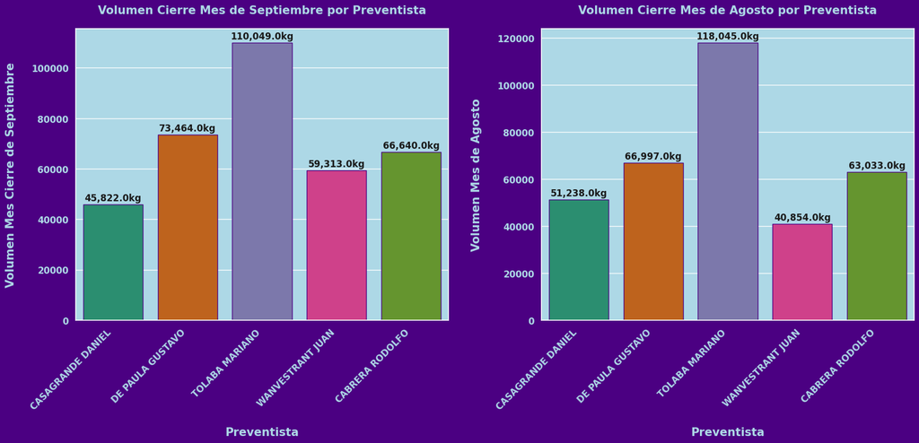

```python
sns.set_style('darkgrid')
sns.set_theme(rc={'axes.facecolor':'lightblue', 'figure.facecolor':'indigo'})
plt.figure(figsize=(20,7))
plt.subplot(1, 2, 1)
ax = sns.barplot(y=data2['Volumen_Cierre_Mes_Septiembre'], x=Volumen_Cierre_Mes_Septiembre['Nombre'], edgecolor='indigo', hue=data['Nombre'], palette='Dark2')
plt.title('Volumen Cierre Mes de Septiembre por Preventista', color='lightblue', size=15, weight='bold',pad=20)
plt.ylabel('Volumen Mes Cierre de Septiembre', color='lightblue', size=15, weight='bold',labelpad=20)
plt.xlabel('Preventista', color='lightblue', size=15, weight='bold',labelpad=20)
plt.xticks(ha='right', color='lightblue', size=12, weight='bold', rotation=45)
plt.yticks(color='lightblue', size=12, weight='bold')
for container in ax.containers:
    ax.bar_label(container,
                label_type='edge',
                padding=2,
                color='k',
                fontsize=12,
                fontweight='bold',
                fmt='{:,.1f}kg')
plt.subplot(1, 2, 2)
ax = sns.barplot(y=data2['Volumen_Cierre_Mes_Agosto'], x=volumen_cierre_mes_de_agosto['Nombre'], edgecolor='indigo', hue=data['Nombre'], palette='Dark2')
plt.title('Volumen Cierre Mes de Agosto por Preventista', color='lightblue', size=15, weight='bold',pad=20)
plt.ylabel('Volumen Mes de Agosto', color='lightblue', size=15, weight='bold',labelpad=20)
plt.xlabel('Preventista', color='lightblue', size=15, weight='bold',labelpad=20)
plt.xticks(ha='right', color='lightblue', size=12, weight='bold', rotation=45)
plt.yticks(color='lightblue', size=12, weight='bold')
for container in ax.containers:
    ax.bar_label(container,
                label_type='edge',
                padding=2,
                color='k',
                fontsize=12,
                fontweight='bold',
                fmt='{:,.1f}kg')
plt.subplots_adjust(wspace=0.25)
plt.show()
```

```python
valor_maximo_volumen_act = data2[['Nombre', 'Volumen_Act']]
valor_maximo_volumen_act = valor_maximo_volumen_act['Volumen_Act'].max()
valor_maximo_volumen_act
```

```
74860
```

```python
valor_minimo_volumen_act = data2[['Nombre', 'Volumen_Act']]
valor_minimo_volumen_act = valor_minimo_volumen_act['Volumen_Act'].min()
valor_minimo_volumen_act
```

```
33068
```

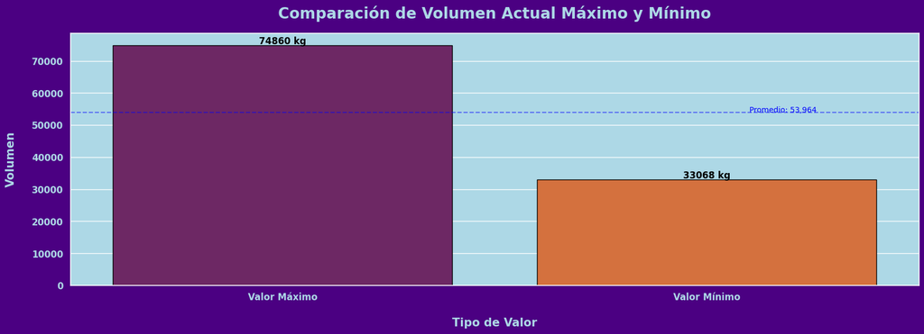

```python
datos_comparacion = pd.DataFrame({
    'Tipo': ['Valor Máximo', 'Valor Mínimo'],
    'Volumen': [74860, 33068]  # valores máximo y mínimo
})

sns.set_style('darkgrid')
sns.set_theme(rc={'axes.facecolor':'lightblue', 'figure.facecolor':'indigo'})
plt.figure(figsize=(20,6))
ax = sns.barplot(x='Tipo', y='Volumen', data=datos_comparacion, palette='inferno', hue='Tipo', edgecolor='black')
plt.title('Comparación de Volumen Actual Máximo y Mínimo', size=20, pad=20, fontweight='bold',color='lightblue')
plt.xlabel('Tipo de Valor', size=15, fontweight='bold',color='lightblue',labelpad=20)
plt.ylabel('Volumen', size=15, fontweight='bold',color='lightblue',labelpad=20)
plt.xticks(color='lightblue', size=12, weight='bold')
plt.yticks(color='lightblue', size=12, weight='bold')
for p in ax.patches:
  ax.annotate(f'{p.get_height():.0f} kg',
  (p.get_x() + p.get_width() / 2., p.get_height()),
  ha='center', va='center',
  xytext=(0,5),
              textcoords='offset points',
  color='black', weight='bold', size=12)

# Agregar una línea horizontal que representa el promedio
promedio = (74860 + 33068) / 2
plt.axhline(y=promedio, color='blue', linestyle='--', alpha=0.5)
plt.text(1.1, promedio, f'Promedio: {promedio:,.0f}',
         fontsize=10, color='blue')

plt.show()
```

```python
data2
```

|  | Nombre | Volumen_Act | Prom_Act | %_Bonif | %_Dev | Volumen_Mes_Sep | Prom_Sep | Var_Mes_Sep | Volumen_Cierre_Mes_Septiembre | Volumen_Cierre_Mes_Agosto |
| --- | --- | --- | --- | --- | --- | --- | --- | --- | --- | --- |
| 0 | CASAGRANDE DANIEL | 37035 | 1683 | 10.9 | 1.7 | 32919 | 1496 | 12.5 | 45822 | 51238 |
| 1 | DE PAULA GUSTAVO | 48152 | 2189 | 10.0 | 1.0 | 47806 | 2173 | 0.7 | 73464 | 66997 |
| 2 | TOLABA MARIANO | 74860 | 3403 | 16.8 | 0.5 | 72528 | 3297 | 3.2 | 110049 | 118045 |
| 3 | WANVESTRANT JUAN | 33068 | 1503 | 9.6 | 1.0 | 27648 | 1257 | 19.6 | 59313 | 40854 |
| 4 | CABRERA RODOLFO | 45256 | 2057 | 10.4 | 0.7 | 45716 | 2078 | -1.0 | 66640 | 63033 |

```python
comparacion_periodo_actual_septiembre_agosto = data2.iloc[:, [0,1,8,9]]
comparacion_periodo_actual_septiembre_agosto
```

|  | Nombre | Volumen_Act | Volumen_Cierre_Mes_Septiembre | Volumen_Cierre_Mes_Agosto |
| --- | --- | --- | --- | --- |
| 0 | CASAGRANDE DANIEL | 37035 | 45822 | 51238 |
| 1 | DE PAULA GUSTAVO | 48152 | 73464 | 66997 |
| 2 | TOLABA MARIANO | 74860 | 110049 | 118045 |
| 3 | WANVESTRANT JUAN | 33068 | 59313 | 40854 |
| 4 | CABRERA RODOLFO | 45256 | 66640 | 63033 |

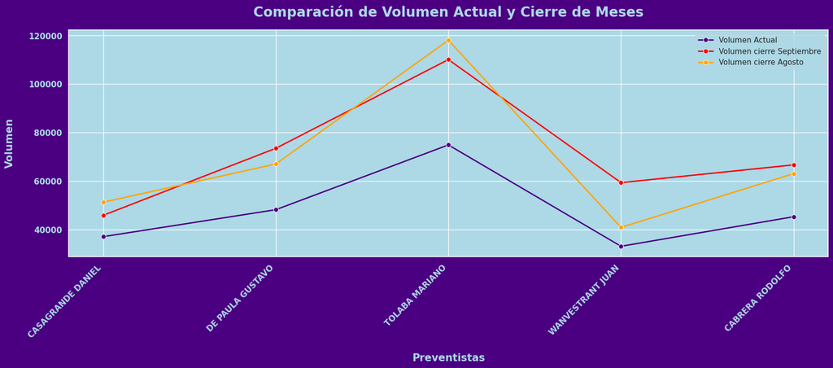

```python
sns.set_style('darkgrid')
sns.set_theme(rc={'axes.facecolor':'lightblue', 'figure.facecolor':'indigo'})
plt.figure(figsize=(20,6))
sns.lineplot(data=comparacion_periodo_actual_septiembre_agosto, x='Nombre', y='Volumen_Act', color='indigo', label='Volumen Actual', marker='o', markersize=7, linewidth=2)
sns.lineplot(data=comparacion_periodo_actual_septiembre_agosto, x='Nombre', y='Volumen_Cierre_Mes_Septiembre', color='red',label='Volumen cierre Septiembre', marker='o', markersize=7, linewidth=2)
sns.lineplot(data=comparacion_periodo_actual_septiembre_agosto, x='Nombre', y='Volumen_Cierre_Mes_Agosto', color='orange',label='Volumen cierre Agosto', marker='o', markersize=7, linewidth=2)
plt.title('Comparación de Volumen Actual y Cierre de Meses', color='lightblue', size=20, weight='bold',pad=20)
plt.xlabel('Preventistas', color='lightblue', size=15, weight='bold',labelpad=20)
plt.ylabel('Volumen', color='lightblue', size=15, weight='bold',labelpad=20)
plt.xticks(rotation=45, ha='right', color='lightblue', size=12, weight='bold')
plt.yticks(color='lightblue', size=12, weight='bold')
plt.legend(loc='upper right')
plt.show()
```

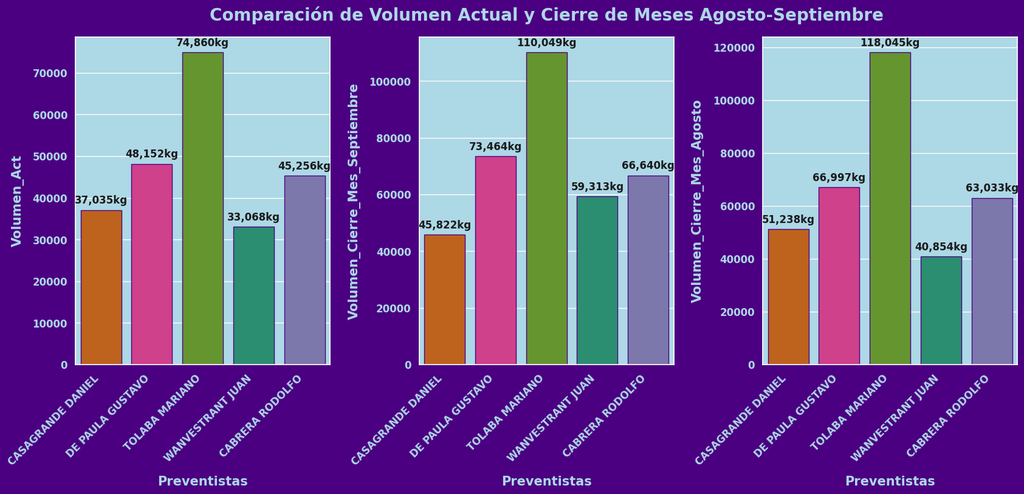

```python
sns.set_style('darkgrid')
sns.set_theme(rc={'axes.facecolor':'lightblue', 'figure.facecolor':'indigo'})
plt.figure(figsize=(20,7))
plt.subplot(1, 3, 1)
ax = sns.barplot(data=comparacion_periodo_actual_septiembre_agosto, x='Nombre', y='Volumen_Act', hue='Volumen_Act', palette='Dark2', edgecolor='indigo')
#plt.title('Comparación de Volumen Actual y Cierre de Meses', color='lightblue', size=20, weight='bold',pad=20)
plt.ylabel('Volumen_Act', color='lightblue', size=15, weight='bold',labelpad=10)
plt.xlabel('Preventistas', color='lightblue', size=15, weight='bold',labelpad=10)
plt.xticks(color='lightblue', size=12, weight='bold', rotation=45, ha='right')
plt.yticks(color='lightblue', size=12, weight='bold')
for container in ax.containers:
    ax.bar_label(container,
                label_type='edge',
                padding=5,
                color='k',
                fontsize=12,
                fontweight='bold',
                fmt='{:,.0f}kg')
plt.legend().remove()

plt.subplot(1, 3, 2)
ax = sns.barplot(data=comparacion_periodo_actual_septiembre_agosto, x='Nombre', y='Volumen_Cierre_Mes_Septiembre', hue='Volumen_Act', palette='Dark2', edgecolor='indigo')
plt.title('Comparación de Volumen Actual y Cierre de Meses Agosto-Septiembre', color='lightblue', size=20, weight='bold',pad=20)
plt.ylabel('Volumen_Cierre_Mes_Septiembre', color='lightblue', size=15, weight='bold',labelpad=10)
plt.xlabel('Preventistas', color='lightblue', size=15, weight='bold',labelpad=10)
plt.xticks(color='lightblue', size=12, weight='bold', rotation=45, ha='right')
plt.yticks(color='lightblue', size=12, weight='bold')
for container in ax.containers:
    ax.bar_label(container,
                label_type='edge',
                padding=5,
                color='k',
                fontsize=12,
                fontweight='bold',
                fmt='{:,.0f}kg')

plt.legend().remove()

plt.subplot(1, 3, 3)
ax = sns.barplot(data=comparacion_periodo_actual_septiembre_agosto, x='Nombre', y='Volumen_Cierre_Mes_Agosto', hue='Volumen_Act', palette='Dark2', edgecolor='indigo')
#plt.title('Comparación de Volumen Actual y Cierre de Meses', color='lightblue', size=20, weight='bold',pad=20)
plt.ylabel('Volumen_Cierre_Mes_Agosto', color='lightblue', size=15, weight='bold',labelpad=10)
plt.xlabel('Preventistas', color='lightblue', size=15, weight='bold',labelpad=10)
plt.xticks(color='lightblue', size=12, weight='bold', rotation=45, ha='right')
plt.yticks(color='lightblue', size=12, weight='bold')
for container in ax.containers:
    ax.bar_label(container,
                label_type='edge',
                padding=5,
                color='k',
                fontsize=12,
                fontweight='bold',
                fmt='{:,.0f}kg')

plt.legend().remove()
plt.subplots_adjust(wspace=0.35)
plt.show()
```

```python
# 1. Paso - Carga y limpieza inicial
def paso1_limpieza(df):
    # Crear copia para no modificar el original
    df_clean = df.copy()
    # Convertir porcentajes a decimales
    df_clean['%_Bonif'] = df_clean['%_Bonif'] / 100
    df_clean['%_Dev'] = df_clean['%_Dev'] / 100
    df_clean['Var_Mes_Sep'] = df_clean['Var_Mes_Sep'] / 100
    return df_clean

# 2. Paso - Cálculo de métricas por preventista
def paso2_metricas_preventista(df):
    df_metrics = df.copy()
    # Calcular volumen neto (considerando %_Bonificaciones y devoluciones)
    df_metrics['Volumen_Neto'] = df_metrics['Volumen_Act'] * (1 - df_metrics['%_Bonif'] - df_metrics['%_Dev'])
    # Calcular variación respecto al mes anterior
    df_metrics['Var_Mes_Anterior'] = ((df_metrics['Volumen_Cierre_Mes_Septiembre'] -
                                     df_metrics['Volumen_Cierre_Mes_Agosto']) /
                                     df_metrics['Volumen_Cierre_Mes_Agosto'])
    return df_metrics

# 3. Paso - Ranking y categorización
def paso3_ranking(df):
    df_ranked = df.copy()
    # Ranking por volumen actual
    df_ranked['Ranking_Volumen'] = df_ranked['Volumen_Act'].rank(ascending=False)
    # Categorizar por desempeño
    df_ranked['Categoria'] = pd.qcut(df_ranked['Volumen_Act'],
                                   q=3,
                                   labels=['Bajo', 'Medio', 'Alto'])
    return df_ranked

# 4. Paso - Análisis de tendencias
def paso4_tendencias(df):
    df_trends = df.copy()
    # Calcular promedios móviles
    df_trends['Tendencia'] = np.where(
        df_trends['Var_Mes_Sep'] > 0.05, 'Creciente',
        np.where(df_trends['Var_Mes_Sep'] < -0.05, 'Decreciente', 'Estable')
    )
    return df_trends

# 5. Paso - Resumen y KPIs
def paso5_resumen(df):
    resumen = {
        'Total_Volumen': df['Volumen_Act'].sum(),
        'Promedio_%_Bonif': df['%_Bonif'].mean(),
        'Max_Volumen': df['Volumen_Act'].max(),
        'Min_Volumen': df['Volumen_Act'].min(),
        'Preventistas_Crecimiento': (df['Var_Mes_Sep'] > 0).sum(),
        'Preventistas_Decrecimiento': (df['Var_Mes_Sep'] < 0).sum()
    }
    return pd.Series(resumen)

# Función principal que ejecuta todos los pasos
def analisis_completo(df_original):
    print("=== ANÁLISIS ESCALONADO DE DATOS DE VENTAS ===\n")

    print("Paso 1: Limpieza de datos")
    df_limpio = paso1_limpieza(df_original)
    print("- Datos normalizados y limpios\n")

    print("Paso 2: Cálculo de métricas por preventista")
    df_metricas = paso2_metricas_preventista(df_limpio)
    print("- Métricas calculadas\n")

    print("Paso 3: Ranking y categorización")
    df_ranking = paso3_ranking(df_metricas)
    print("- Rankings establecidos\n")

    print("Paso 4: Análisis de tendencias")
    df_tendencias = paso4_tendencias(df_ranking)
    print("- Tendencias identificadas\n")

    print("Paso 5: Resumen y KPIs")
    resumen = paso5_resumen(df_tendencias)
    print("\nResumen del análisis:")
    print(resumen)

    return df_tendencias

# Ejemplo de uso:
resultado_final = analisis_completo(data)
print(' ')
resultado_final
```

```
=== ANÁLISIS ESCALONADO DE DATOS DE VENTAS ===

Paso 1: Limpieza de datos
- Datos normalizados y limpios

Paso 2: Cálculo de métricas por preventista
- Métricas calculadas

Paso 3: Ranking y categorización
- Rankings establecidos

Paso 4: Análisis de tendencias
- Tendencias identificadas

Paso 5: Resumen y KPIs

Resumen del análisis:
Total_Volumen                 238371.0000
Promedio_%_Bonif                   0.1154
Max_Volumen                    74860.0000
Min_Volumen                    33068.0000
Preventistas_Crecimiento           4.0000
Preventistas_Decrecimiento         1.0000
dtype: float64
```

|  | Nombre | Volumen_Act | Prom_Act | %_Bonif | %_Dev | Volumen_Mes_Sep | Prom_Sep | Var_Mes_Sep | Volumen_Cierre_Mes_Septiembre | Volumen_Cierre_Mes_Agosto | Volumen_Neto | Var_Mes_Anterior | Ranking_Volumen | Categoria | Tendencia |
| --- | --- | --- | --- | --- | --- | --- | --- | --- | --- | --- | --- | --- | --- | --- | --- |
| 0 | CASAGRANDE DANIEL | 37035 | 1683 | 0.109 | 0.017 | 32919 | 1496 | 0.125 | 45822 | 51238 | 32368.590 | -0.105703 | 4.0 | Bajo | Creciente |
| 1 | DE PAULA GUSTAVO | 48152 | 2189 | 0.100 | 0.010 | 47806 | 2173 | 0.007 | 73464 | 66997 | 42855.280 | 0.096527 | 2.0 | Alto | Estable |
| 2 | TOLABA MARIANO | 74860 | 3403 | 0.168 | 0.005 | 72528 | 3297 | 0.032 | 110049 | 118045 | 61909.220 | -0.067737 | 1.0 | Alto | Estable |
| 3 | WANVESTRANT JUAN | 33068 | 1503 | 0.096 | 0.010 | 27648 | 1257 | 0.196 | 59313 | 40854 | 29562.792 | 0.451828 | 5.0 | Bajo | Creciente |
| 4 | CABRERA RODOLFO | 45256 | 2057 | 0.104 | 0.007 | 45716 | 2078 | -0.010 | 66640 | 63033 | 40232.584 | 0.057224 | 3.0 | Medio | Estable |

```python
# Crear lista con los valores de Volumen_Act
volumen_act = [37035, 48152, 74860, 33068, 45256]

# Crear DataFrame
df = pd.DataFrame({'Volumen_Act': volumen_act})

# Calcular estadísticas
stats = {
    'Promedio': np.mean(volumen_act),
    'Valor Mínimo': np.min(volumen_act),
    'Valor Máximo': np.max(volumen_act),
    'Desviación Estándar': np.std(volumen_act)
}

# Mostrar resultados
print("Estadísticas de Volumen_Act:")
for key, value in stats.items():
    print(f"{key}: {value:,.2f}")

# Mostrar valores por encima y por debajo del promedio
promedio = stats['Promedio']
print("\nAnálisis respecto al promedio:")
for valor in volumen_act:
    diferencia = valor - promedio
    estado = "por encima" if diferencia > 0 else "por debajo"
    print(f"Valor {valor:,}: {abs(diferencia):,.2f} {estado} del promedio")
```

```
Estadísticas de Volumen_Act:
Promedio: 47,674.20
Valor Mínimo: 33,068.00
Valor Máximo: 74,860.00
Desviación Estándar: 14,640.20

Análisis respecto al promedio:
Valor 37,035: 10,639.20 por debajo del promedio
Valor 48,152: 477.80 por encima del promedio
Valor 74,860: 27,185.80 por encima del promedio
Valor 33,068: 14,606.20 por debajo del promedio
Valor 45,256: 2,418.20 por debajo del promedio
```

```python
"""
#@title Convert ipynb to HTML in Colab
# Upload ipynb
from google.colab import files
f = files.upload()

# Convert ipynb to html
import subprocess
file0 = list(f.keys())[0]
_ = subprocess.run(["pip", "install", "nbconvert"])
_ = subprocess.run(["jupyter", "nbconvert", file0, "--to", "html"])

# download the html
files.download(file0[:-5]+"html")
"""
```

[output not shown]

## Informe del Trabajo Realizado con los Datos de Ventas

Se ha realizado un análisis exhaustivo de los datos de ventas de los preventistas. El proceso se dividió en cinco pasos: limpieza de datos, cálculo de métricas por preventista, ranking y categorización, análisis de tendencias, y resumen con KPIs.

**Paso 1: Limpieza de datos**

En este primer paso, se normalizaron y limpiaron los datos. Los porcentajes de bonificación, devolución y variación del mes de septiembre se convirtieron a decimales para facilitar su manipulación.

**Paso 2: Cálculo de métricas por preventista**

Se calcularon dos métricas importantes para cada preventista:

- El **volumen neto**, que considera las bonificaciones y devoluciones.
- La **variación respecto al mes anterior**, que indica el cambio porcentual en el volumen de cierre entre septiembre y agosto.

**Paso 3: Ranking y categorización**

Se estableció un ranking de los preventistas en función de su volumen actual, asignando el puesto 1 al de mayor volumen.

- **Tolaba Mariano** obtuvo el primer puesto con un volumen de 74860.
- **Wanvestrant Juan** se ubicó en el último puesto con un volumen de 33068.

También se categorizó a los preventistas en tres grupos según su desempeño (alto, medio, bajo), utilizando el volumen actual como criterio.

**Paso 4: Análisis de tendencias**

Se identificaron las tendencias de cada preventista analizando la variación del mes de septiembre. Si la variación superaba el 5%, se consideró una tendencia creciente; si era inferior al -5%, se consideró decreciente; y entre estos valores, se clasificó como estable.

**Paso 5: Resumen y KPIs**

Se generaron gráficos para visualizar los datos de manera clara y concisa, incluyendo:

- Gráficos de barras que muestran el volumen actual, el promedio actual, el porcentaje de bonificación, el porcentaje de devolución, el volumen del mes de septiembre, y la variación del mes de septiembre por preventista.
- Gráficos de barras que comparan el volumen de cierre de septiembre y agosto.
- Un gráfico de barras que compara el volumen actual máximo y mínimo, incluyendo una línea que representa el promedio.
- Un gráfico de líneas que compara el volumen actual, el volumen de cierre de septiembre y el volumen de cierre de agosto.
- Gráficos de barras que comparan el volumen actual, el volumen de cierre de septiembre y el volumen de cierre de agosto, con el volumen actual como indicador de color.

Este análisis proporciona una visión detallada del rendimiento de ventas de cada preventista, permitiendo identificar áreas de mejora y tomar decisiones estratégicas para optimizar las ventas.